# ETC1010 Assignment 3

Team CJ

#### 1. Reading in the Melbourne housing data

```r
library(tidyverse)
houses <- read_csv("data/Melbourne_housing_FULL.csv")
```

#### 2. Focusing ONLY on the variables Price, Rooms, Type, Distance, Bedroom2, Bathroom

- Price: price in dollars
- Rooms: number of rooms
- Type:
  - **br**: bedroom(s);
  - **h**: house, cottage, villa, semi, terrace;
  - **u**: unit, duplex;
  - **t**: townhouse;
  - **dev site**: development site;
  - **o res**: other residential.
- Distance: distance from CBD
- Bedroom2: number of bedrooms
- Bathroom: number of bathrooms

```r
Focus <- subset(houses, select = c(Price, Rooms, Type, Distance, Bedroom2, Bathroom))
Focus
```

```
## # A tibble: 34,857 x 6
##      Price Rooms Type  Distance Bedroom2 Bathroom
##      <int> <int> <chr>    <dbl>    <int>    <int>
##  1      NA     2 h         2.50        2        1
##  2 1480000     2 h         2.50        2        1
##  3 1035000     2 h         2.50        2        1
##  4      NA     3 u         2.50        3        2
##  5 1465000     3 h         2.50        3        2
##  6  850000     3 h         2.50        3        2
##  7 1600000     4 h         2.50        3        1
##  8      NA     4 h         2.50        3        2
##  9      NA     2 h         2.50        4        1
## 10      NA     2 h         2.50        3        2
## # ... with 34,847 more rows
```

#### 3. Make a missing values summary, and a strategy for dealing with the missings

##### Missingness map

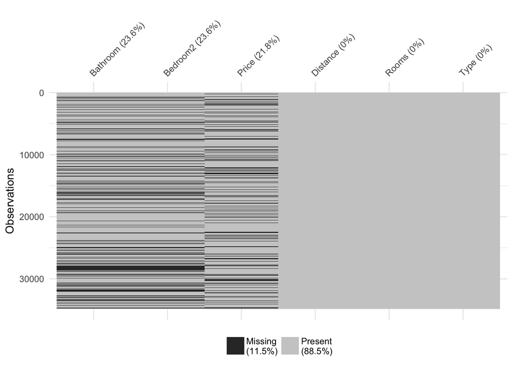

```r
library(visdat)
library(naniar)
vis_miss(Focus, sort_miss=TRUE)
```

##### Missing values summary and proportion of observations missing

```r
s_miss <- miss_summary(Focus)
# Missing observations
s_miss$miss_df_prop
```

```
## [1] 0.1150128
```

```r
# Missing variables
s_miss$miss_var_summary
```

```
## [[1]]
## # A tibble: 6 x 4
##   variable n_miss pct_miss n_miss_cumsum
##   <chr>     <int>    <dbl>         <int>
## 1 Price      7610 21.8              7610
## 2 Rooms         0  0.               7610
## 3 Type          0  0.               7610
## 4 Distance      1  0.00287          7611
## 5 Bedroom2   8217 23.6             15828
## 6 Bathroom   8226 23.6             24054
```

### Strategy for dealing with missing values

- Although 22% of the price values are missing, it is too risky to impute values for price because price is the response variable in the model. We’ll therefore ignore the observations with missing prices.
- Need to find a way to impute values for number of bedrooms and bathrooms (~20% of the data is missing - quite large)

```r
source("https://bioconductor.org/biocLite.R")
```

```
## Bioconductor version 3.6 (BiocInstaller 1.28.0), ?biocLite for help
```

```r
biocLite("impute")
```

```
## BioC_mirror: https://bioconductor.org
```

```
## Using Bioconductor 3.6 (BiocInstaller 1.28.0), R 3.4.3 (2017-11-30).
```

```
## Installing package(s) 'impute'
```

[output not shown]

[output not shown]

```r
library(impute)
```

```r
# Dropping the missing values in price variable
Focus <- Focus %>%
  filter(!is.na(Price))
```

We will use the mean imputation method to impute the missing data in Bathroom and Bedroom2 because the k-nearest neighbours method results in the program not having enough memory to compute the data.

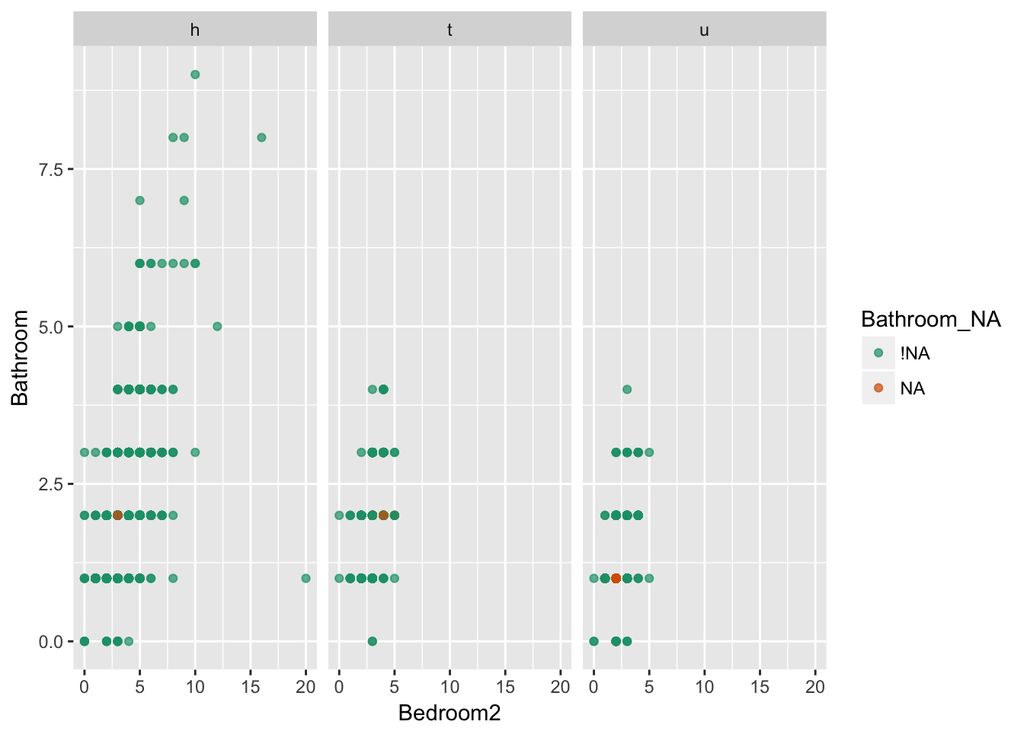

```r
# Using the mean imputation method to impute missing data in Bathroom and Bedroom2 variables for each house type
fh <- bind_shadow(Focus) %>%
  filter(Type=="h") %>%
  mutate(Bedroom2= ifelse(is.na(Bedroom2),
                             mean(Bedroom2, na.rm=TRUE),
                             Bedroom2),
         Bathroom = ifelse(is.na(Bathroom),
                             mean(Bathroom, na.rm=TRUE),
                             Bathroom))

ft <- bind_shadow(Focus) %>%
  filter(Type=="t") %>%
  mutate(Bedroom2 = ifelse(is.na(Bedroom2),
                             mean(Bedroom2, na.rm=TRUE),
                             Bedroom2),
         Bathroom = ifelse(is.na(Bathroom),
                             mean(Bathroom, na.rm=TRUE),
                             Bathroom))

fu <- bind_shadow(Focus) %>%
  filter(Type=="u") %>%
  mutate(Bedroom2 = ifelse(is.na(Bedroom2),
                             mean(Bedroom2, na.rm=TRUE),
                             Bedroom2),
         Bathroom = ifelse(is.na(Bathroom),
                             mean(Bathroom, na.rm=TRUE),
                             Bathroom))

Focus_shadow <- bind_rows(fh, ft, fu)

# Rounding imputations for Bedroom2 and Bathroom to nearest whole number
round_df <- function(x, digits) {
    # round all numeric variables
    # x: data frame
    # digits: number of digits to round
    numeric_columns <- sapply(x, mode) == 'numeric'
    x[numeric_columns] <-  round(x[numeric_columns], digits)
    x
}

Focus_shadow <- Focus_shadow %>%
  mutate(Bedroom2 = round_df(Focus_shadow$Bedroom2, 0),
         Bathroom = round_df(Focus_shadow$Bathroom, 0))

# Plotting the imputed values against missing values
ggplot(Focus_shadow,
       aes(x = Bedroom2,
           y = Bathroom,
           colour=Bathroom_NA)) +
  geom_point(alpha=0.7) +
  facet_wrap(~Type) +
  scale_colour_brewer(palette="Dark2")
```

#### What we learn from the plot: - The imputed values are closer to the complete case values - and they are inside the range of complete values, thus possibly suggesting a good model fit.

### Plots summarising the relationship between price

```r
# Filtering data for necessary variables only
Focus_complete <- Focus_shadow %>%
  select(Price, Rooms, Type, Distance, Bedroom2, Bathroom)
Focus_complete
```

```
## # A tibble: 27,247 x 6
##      Price Rooms Type  Distance Bedroom2 Bathroom
##      <int> <int> <chr>    <dbl>    <dbl>    <dbl>
##  1 1480000     2 h         2.50       2.       1.
##  2 1035000     2 h         2.50       2.       1.
##  3 1465000     3 h         2.50       3.       2.
##  4  850000     3 h         2.50       3.       2.
##  5 1600000     4 h         2.50       3.       1.
##  6  941000     2 h         2.50       2.       1.
##  7 1876000     3 h         2.50       4.       2.
##  8 1636000     2 h         2.50       2.       1.
##  9 1000000     3 h         2.50       3.       2.
## 10 1097000     2 h         2.50       3.       1.
## # ... with 27,237 more rows
```

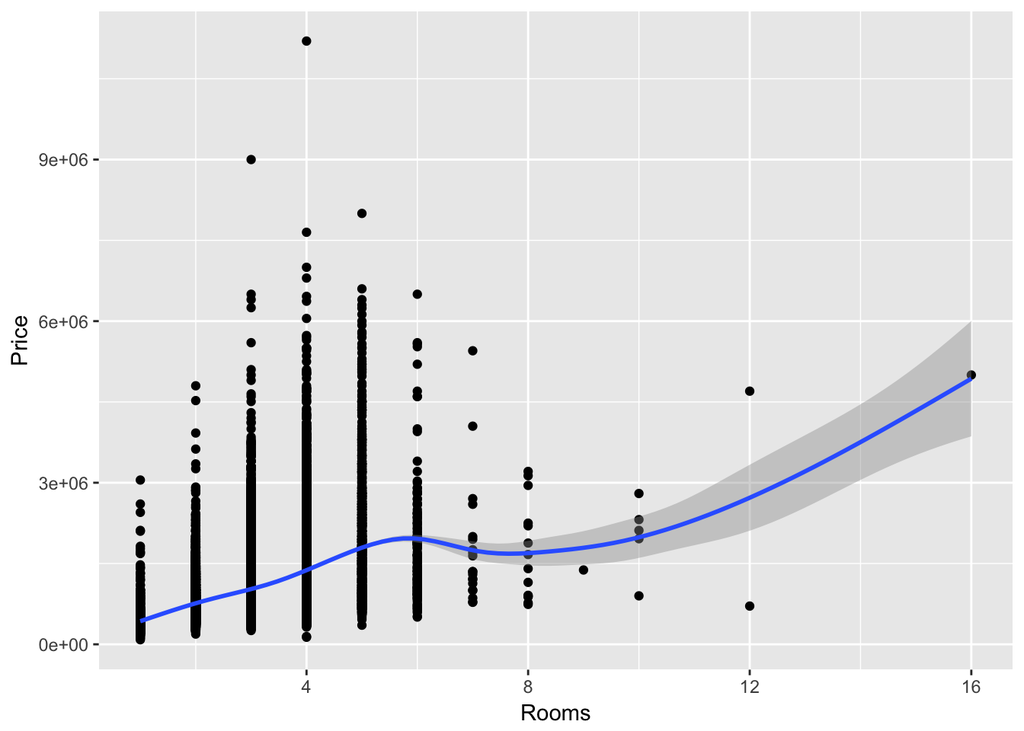

```r
ggplot(Focus_complete, aes(x=Rooms, y=Price)) +
  geom_point() +
  geom_smooth()
```

From here, we can see a somewhat weak positive relationship between the number of rooms and house price. It appears to be somewhat normally distributed, barring the more extreme values of homes with more than 10 rooms. This seems to make sense, as the more rooms a house has, the more likely it is to be of higher quality. Perhaps when the number of rooms increases too high, the quality of the house decreases, resulting in a lower price.

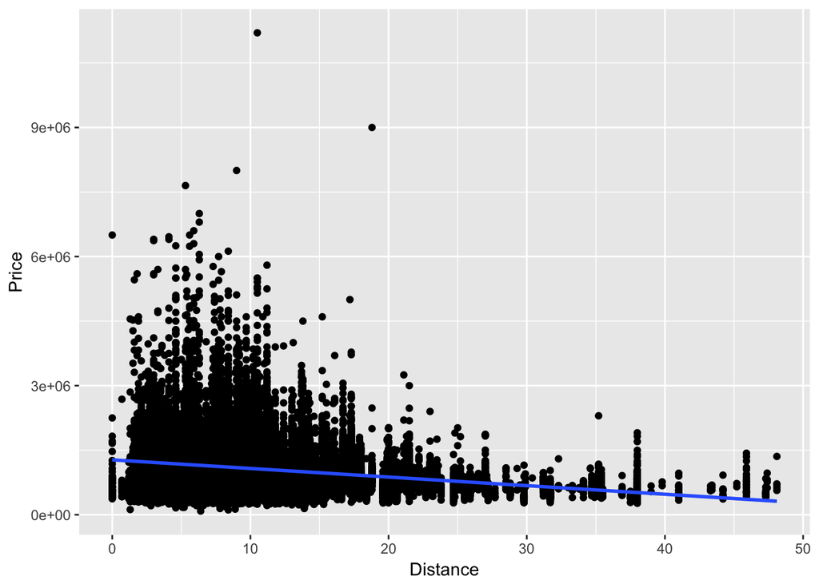

```r
ggplot(Focus_complete, aes(x=Distance, y=Price)) +
  geom_point() +
  geom_smooth(method = "lm")
```

Here, we can see a weak negative relationship between price and the house’s distance from the CBD, which makes sense, as the further away the home is, the less attractive the house would be for people who work in the city or travel to the city often.

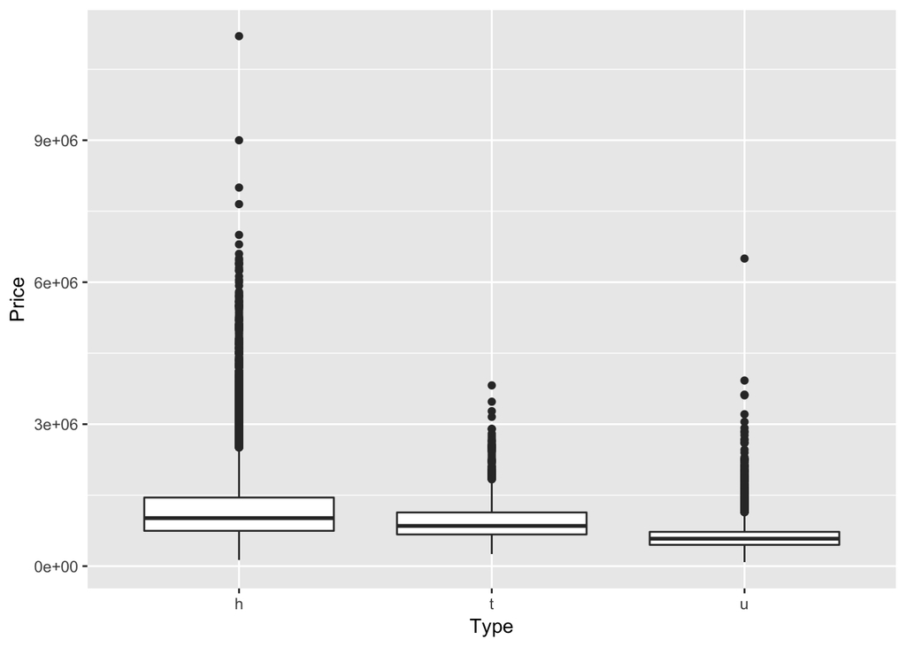

```r
ggplot(Focus_complete, aes(x=Type, y=Price)) +
  geom_boxplot() +
  geom_smooth(method = "lm")
```

## Building the model, explaining your choices of transformations, variable selection, interactions

### Transformations

```r
Focus_complete <- Focus_complete %>%
  mutate(Type_c = factor(Type, ordered = FALSE)) %>%
  mutate(Distance_log = log10(Distance)) %>%
  filter(Rooms <= 10) %>%
  filter(Distance_log != -Inf)
```

```r
library(broom)
focus_fit <- lm(Price~ I(Rooms^2) * Bedroom2* Bathroom * Type_c * + I(Distance_log^2) * Type_c+ Type_c * Rooms * Distance_log, data =Focus_complete)
glance(focus_fit)
```

```
##   r.squared adj.r.squared    sigma statistic p.value df    logLik      AIC
## 1  0.479635     0.4785608 462244.4  446.5113       0 57 -393142.3 786400.7
##        BIC     deviance df.residual
## 1 786876.9 5.796436e+15       27128
```

#### Observed vs fitted

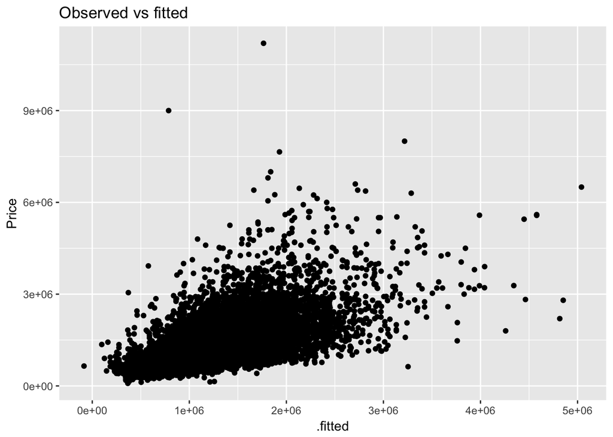

```r
focus_model <- augment(focus_fit, Focus_complete)
ggplot(focus_model, aes(x=.fitted, y=Price)) +
  geom_point()+ ggtitle("Observed vs fitted")
```

#### Residuals vs fitted

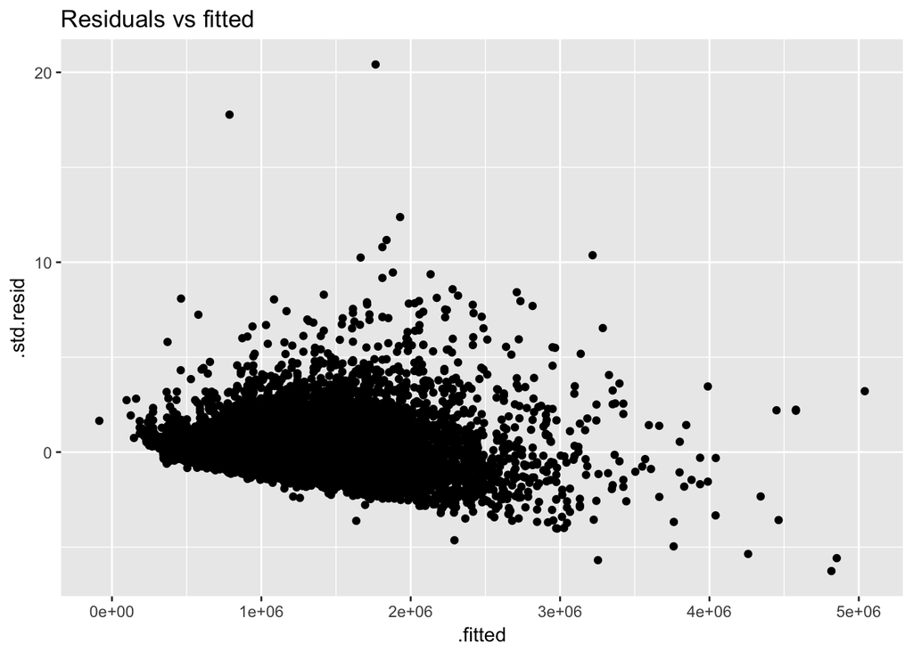

```r
ggplot(focus_model, aes(x=.fitted, y=.std.resid)) +
  geom_point() + ggtitle("Residuals vs fitted")
```

# Summarise your final model, and justify why you think it is the best

```r
tidy(focus_fit)
```

```
##                                                      term      estimate
## 1                                             (Intercept)  -199155.2972
## 2                                              I(Rooms^2)  -167032.7167
## 3                                                Bedroom2   -85184.9225
## 4                                                Bathroom  -172640.2519
## 5                                                 Type_ct   724900.6311
## 6                                                 Type_cu   931601.9111
## 7                                       I(Distance_log^2)  -605773.7643
## 8                                                   Rooms  1007640.9898
## 9                                            Distance_log  1257610.5922
## 10                                    I(Rooms^2):Bedroom2    15604.7235
## 11                                    I(Rooms^2):Bathroom    71629.9638
## 12                                      Bedroom2:Bathroom    30797.1524
## 13                                     I(Rooms^2):Type_ct   -50044.8364
## 14                                     I(Rooms^2):Type_cu   295466.1190
```

[output cut: 101 more lines]